# Statistical Inference with Repeated Measures (EEG) data

Livio Finos

# 1 Introduction

```r
knitr::opts_chunk$set(echo = TRUE)
```

## 1.1 The data

**(Fictitious data)**

ERP experiment

- 20 Subjects,
- 6 Channels: O1, O2, PO7, PO8, P7, P8
- Stimuli: pictures. Conditions:
  - 1 (f): fear (face)
  - 2 (h): happiness (face)
  - 3 (d): disgust (face)
  - 4 (n): neutral (face)
  - 5 (o): object
- Measure: Area around the component P170

Setting parameters, importing the data:

```r
#
# # example of files contents:
# # s01 NC P7 f -7.1121
# # s01 NC P7 h -7.2582
# # s01 NC P7 d -7.4540
# # s01 NC P7 n -5.6729
# # s01 NC P7 o -2.1812
# # s01 NC PO7 f -7.4169
#
#
# library(readr)
# library(dplyr)
#
# dati=lapply(datafiles, read_delim,col_names = FALSE ,delim = " ")
# dati=bind_rows(dati)
# str(dati)
# names(dati)=c("Subj","Group","Chan","Condition","Y")
#
# # Not used in this analysis
# dati$Group=NULL
# dati$Subj=factor(dati$Subj)
# dati$Chan=factor(dati$Chan)
# dati$Condition=factor(dati$Condition)
# str(dati)
# save(dati,file="datiEEG.Rdata")
#
# dati2=subset(dati,(Chan=="O1")&(Condition%in%c("f","n")))
# dati2$Condition=factor(dati2$Condition)
# save(dati2,file="dati2EEG.Rdata")
load("./dataset/datiEEG.Rdata")
load("./dataset/dati2EEG.Rdata")

dati$Condition=factor(dati$Condition,levels=c("o","d","f","h","n"))

# VERY IMPORTANT:
contrasts(dati$Chan) <- contr.sum(6)
contrasts(dati$Condition) <- contr.sum(5)
contrasts(dati$Subj) <- contr.sum(nlevels(dati$Subj))

contrasts(dati2$Condition) <- contr.sum(2)
contrasts(dati2$Subj) <- contr.sum(nlevels(dati2$Subj))
```

## 1.2 Motivation (EDA)

For Channel `O1`:

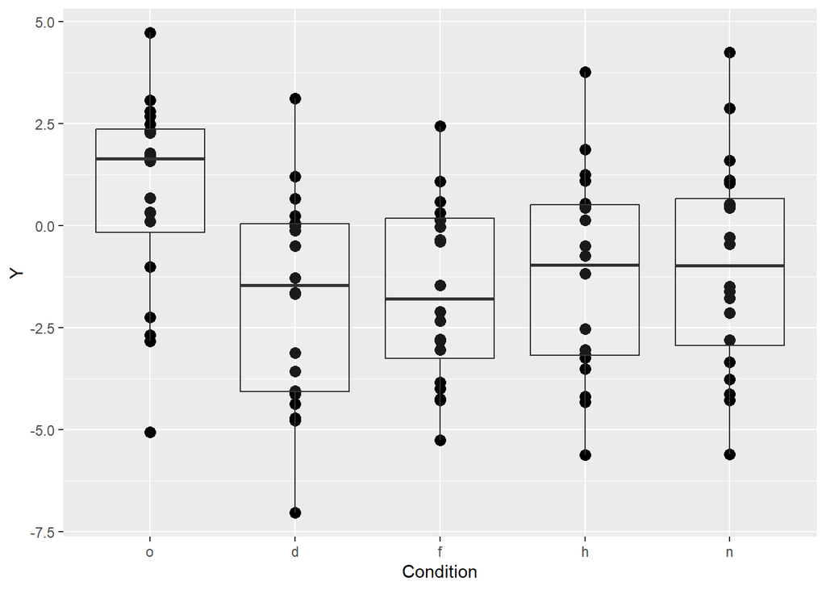

```r
library(ggplot2)
p <- ggplot(subset(dati,Chan=="O1"),aes(Condition,Y))
p+geom_point(size = 3) +geom_boxplot(alpha=.1)
```

Is there a specificity of the subject?

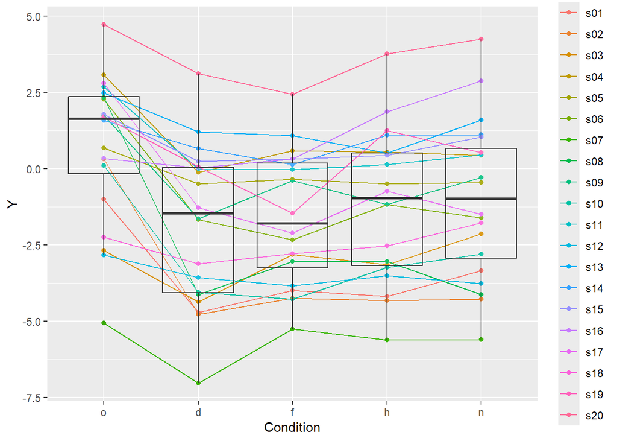

```r
dati01=subset(dati,Chan=="O1")
library(ggplot2)
p <- ggplot(dati01,aes(Condition,Y))
p+geom_point(aes(group = Subj, colour = Subj))+
  geom_line(aes(group = Subj, colour = Subj))+
   geom_boxplot(alpha=.1)
```

We subtract the subject-specific effect (i.e. subject’s mean) to each observation.

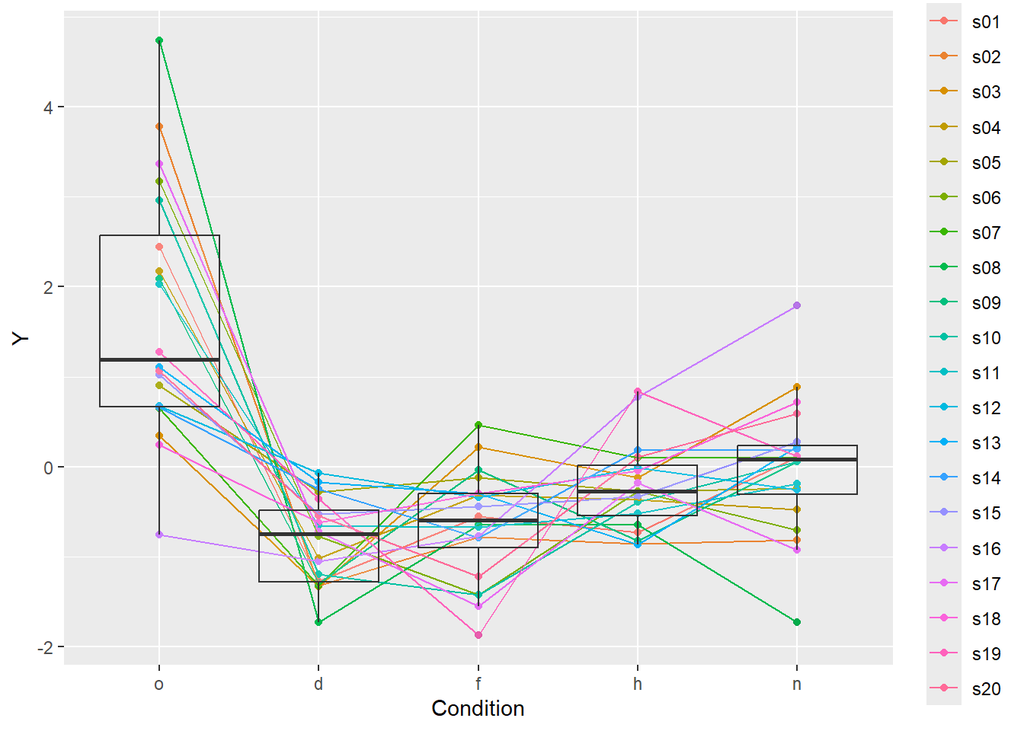

```r
dati01=subset(dati,Chan=="O1")
Y=scale(matrix(dati01$Y,5),scale=FALSE)
dati01$Y=as.vector(Y)

library(ggplot2)
p <- ggplot(dati01,aes(Condition,Y))
p+geom_point(aes(group = Subj, colour = Subj))+
  geom_line(aes(group = Subj, colour = Subj))+
   geom_boxplot(alpha=.1)
```

The dispersion of the data has been largely reduced. This effect is the one taken in account by the models for repeated measures.

# 2 Repeated Measures ANOVA

## 2.1 Introduction

wiki reference: https://en.wikipedia.org/wiki/Repeated_measures_design

A nice explanation can be found (in particular see 7.9 and 7.10):  
Jonathan Baron (2011) Notes on the use of R for psychology experiments and questionnaires https://www.sas.upenn.edu/~baron/from_cattell/rpsych/rpsych.html

and in the Course materal of  
ST 732, Applied Longitudinal Data Analysis, NC State University by Marie Davidian https://www.stat.ncsu.edu/people/davidian/courses/st732/notes/chap5.pdf from https://www.stat.ncsu.edu/people/davidian/courses/st732/

## 2.2 2 conditions, paired observations

Let consider the reduced problem: channel `Chan=="O1` and `Condition=="n"` or `Condition=="f"`.

How to compare the two conditions? First try:

```r
t.test(dati2$Y[dati2$Condition=="n"],
       dati2$Y[dati2$Condition=="f"])
```

```
##
##  Welch Two Sample t-test
##
## data:  dati2$Y[dati2$Condition == "n"] and dati2$Y[dati2$Condition == "f"]
## t = 0.8449, df = 36.861, p-value = 0.4036
## alternative hypothesis: true difference in means is not equal to 0
## 95 percent confidence interval:
##  -0.8868791  2.1552491
## sample estimates:
## mean of x mean of y
## -0.964530 -1.598715
```

Is it ok?

NO! We don’t take in account the fact that measures are taken on the same subject!

```r
t.test(dati2$Y[dati2$Condition=="n"],
       dati2$Y[dati2$Condition=="f"],paired=TRUE)
```

```
##
##  Paired t-test
##
## data:  dati2$Y[dati2$Condition == "n"] and dati2$Y[dati2$Condition == "f"]
## t = 3.287, df = 19, p-value = 0.003877
## alternative hypothesis: true mean difference is not equal to 0
## 95 percent confidence interval:
##  0.2303616 1.0380084
## sample estimates:
## mean difference
##        0.634185
```

```r
## equivalent to
t.test(dati2$Y[dati2$Condition=="n"]-
         dati2$Y[dati2$Condition=="f"])
```

```
##
##  One Sample t-test
##
## data:  dati2$Y[dati2$Condition == "n"] - dati2$Y[dati2$Condition == "f"]
## t = 3.287, df = 19, p-value = 0.003877
## alternative hypothesis: true mean is not equal to 0
## 95 percent confidence interval:
##  0.2303616 1.0380084
## sample estimates:
## mean of x
##  0.634185
```

Can you write it as a linear model?

```r
mod2=lm(Y~ Condition+Subj,data=dati2)

summary(mod2)
```

```
##
## Call:
## lm(formula = Y ~ Condition + Subj, data = dati2)
##
## Residuals:
##     Min      1Q  Median      3Q     Max
## -0.9656 -0.2713  0.0000  0.2713  0.9656
##
## Coefficients:
##             Estimate Std. Error t value Pr(>|t|)
## (Intercept) -1.28162    0.09647 -13.285 4.56e-11 ***
## Condition1  -0.31709    0.09647  -3.287 0.003877 **
## Subj1       -2.38228    0.42050  -5.665 1.84e-05 ***
## Subj2       -2.97278    0.42050  -7.070 9.99e-07 ***
## Subj3       -1.19488    0.42050  -2.842 0.010433 *
## Subj4        1.79392    0.42050   4.266 0.000417 ***
## Subj5        0.88487    0.42050   2.104 0.048892 *
## Subj6       -0.68168    0.42050  -1.621 0.121470
## Subj7       -4.14253    0.42050  -9.851 6.69e-09 ***
## Subj8       -2.30318    0.42050  -5.477 2.77e-05 ***
## Subj9        0.94687    0.42050   2.252 0.036361 *
## Subj10      -2.25578    0.42050  -5.365 3.54e-05 ***
## Subj11       1.50062    0.42050   3.569 0.002049 **
## Subj12      -2.51503    0.42050  -5.981 9.35e-06 ***
## Subj13       2.62622    0.42050   6.246 5.35e-06 ***
## Subj14       1.90672    0.42050   4.534 0.000227 ***
## Subj15       1.96557    0.42050   4.674 0.000165 ***
## Subj16       2.88522    0.42050   6.861 1.51e-06 ***
## Subj17      -0.51293    0.42050  -1.220 0.237463
## Subj18      -0.99723    0.42050  -2.372 0.028436 *
## Subj19       0.81917    0.42050   1.948 0.066330 .
## ---
## Signif. codes:  0 '***' 0.001 '**' 0.01 '*' 0.05 '.' 0.1 ' ' 1
##
## Residual standard error: 0.6101 on 19 degrees of freedom
## Multiple R-squared:  0.9676, Adjusted R-squared:  0.9334
## F-statistic: 28.35 on 20 and 19 DF,  p-value: 3.682e-10
```

```r
anova(mod2)
```

```
## Analysis of Variance Table
##
## Response: Y
##           Df  Sum Sq Mean Sq F value    Pr(>F)
## Condition  1   4.022  4.0219  10.804  0.003877 **
## Subj      19 207.022 10.8959  29.270 3.118e-10 ***
## Residuals 19   7.073  0.3722
## ---
## Signif. codes:  0 '***' 0.001 '**' 0.01 '*' 0.05 '.' 0.1 ' ' 1
```

Compare the results. (Different or the same?)

## 2.3 Linear models with repeated measures

Let’s consider (and fit) a linear model with `Chan*Condition`:

```r
modlmf=lm(Y~ Chan*Condition,data=dati)
anova(modlmf)
```

```
## Analysis of Variance Table
##
## Response: Y
##                 Df Sum Sq Mean Sq F value Pr(>F)
## Chan             5  871.9 174.376 25.4499 <2e-16 ***
## Condition        4 1022.9 255.714 37.3209 <2e-16 ***
## Chan:Condition  20   66.6   3.328  0.4857 0.9719
## Residuals      570 3905.5   6.852
## ---
## Signif. codes:  0 '***' 0.001 '**' 0.01 '*' 0.05 '.' 0.1 ' ' 1
```

We don’t take in account the fact that measures are taken on the same subject!

Can we just add the `Subj` term?

```r
modlmf=lm(Y~ Chan*Condition+Subj,data=dati)
anova(modlmf)
```

```
## Analysis of Variance Table
##
## Response: Y
##                 Df  Sum Sq Mean Sq F value Pr(>F)
## Chan             5  871.88 174.376 68.0714 <2e-16 ***
## Condition        4 1022.86 255.714 99.8233 <2e-16 ***
## Subj            19 2494.02 131.264 51.2418 <2e-16 ***
## Chan:Condition  20   66.56   3.328  1.2992 0.1724
## Residuals      551 1411.48   2.562
## ---
## Signif. codes:  0 '***' 0.001 '**' 0.01 '*' 0.05 '.' 0.1 ' ' 1
```

Answer: yes and no.  
The estimates are ok, but we need to take care of the residuals SS in the testing step.

All the SS that we need can be found in the saturated linear model. We compute them now and we use them later.

```r
modlmf=lm(Y~ Chan*Condition*Subj,data=dati)
anova(modlmf)
```

```
## Analysis of Variance Table
##
## Response: Y
##                      Df  Sum Sq Mean Sq F value Pr(>F)
## Chan                  5  871.88 174.376     NaN    NaN
## Condition             4 1022.86 255.714     NaN    NaN
## Subj                 19 2494.02 131.264     NaN    NaN
## Chan:Condition       20   66.56   3.328     NaN    NaN
## Chan:Subj            95 1017.54  10.711     NaN    NaN
## Condition:Subj       76  246.95   3.249     NaN    NaN
## Chan:Condition:Subj 380  146.99   0.387     NaN    NaN
## Residuals             0    0.00     NaN
```

## 2.4 Repeated measures

```r
# The standard way
mod=aov(Y~ Chan*Condition+Subj + Error(Subj/(Chan*Condition)),data=dati)
summary(mod)
```

```
##
## Error: Subj
##      Df Sum Sq Mean Sq
## Subj 19   2494   131.3
##
## Error: Subj:Chan
##           Df Sum Sq Mean Sq F value   Pr(>F)
## Chan       5  871.9  174.38   16.28 1.42e-11 ***
## Residuals 95 1017.5   10.71
## ---
## Signif. codes:  0 '***' 0.001 '**' 0.01 '*' 0.05 '.' 0.1 ' ' 1
##
## Error: Subj:Condition
##           Df Sum Sq Mean Sq F value Pr(>F)
## Condition  4 1022.9  255.71    78.7 <2e-16 ***
## Residuals 76  246.9    3.25
## ---
## Signif. codes:  0 '***' 0.001 '**' 0.01 '*' 0.05 '.' 0.1 ' ' 1
##
## Error: Subj:Chan:Condition
##                 Df Sum Sq Mean Sq F value Pr(>F)
## Chan:Condition  20  66.56   3.328   8.604 <2e-16 ***
## Residuals      380 146.99   0.387
## ---
## Signif. codes:  0 '***' 0.001 '**' 0.01 '*' 0.05 '.' 0.1 ' ' 1
```

A better output and slightly more compleate analysis (Sphericity Corrections):

```r
library(ez)
mod=ezANOVA(dv=Y, wid=Subj, within=.(Chan,Condition),data=dati,type=3)
print(mod)
```

```
## $ANOVA
##           Effect DFn DFd         F            p p<.05        ges
## 2           Chan   5  95 16.280163 1.422895e-11     * 0.18250183
## 3      Condition   4  76 78.697466 2.998429e-26     * 0.20754506
## 4 Chan:Condition  20 380  8.604227 5.232560e-21     * 0.01675807
##
## $`Mauchly's Test for Sphericity`
##      Effect          W            p p<.05
## 2      Chan 0.03433646 3.910057e-07     *
## 3 Condition 0.06754172 4.802965e-07     *
##
## $`Sphericity Corrections`
##           Effect       GGe        p[GG] p[GG]<.05       HFe        p[HF]
## 2           Chan 0.4368229 3.441213e-06         * 0.4957490 9.287363e-07
## 3      Condition 0.4114825 4.226482e-12         * 0.4454085 6.399344e-13
## 4 Chan:Condition 0.1134660 4.452748e-04         * 0.1296611 2.121437e-04
##   p[HF]<.05
## 2         *
## 3         *
## 4         *
```

To see the relation between repeated measures and linear model, again, the Baron material is a good start. Specially see section “7.9.3 The Appropriate Error Terms”

## 2.5 Spend your DF in a different way!

Same number of DF, but spent in a different way

```r
dati$Lateral=dati$Chan
levels(dati$Lateral)
```

```
## [1] "O1"  "O2"  "P7"  "P8"  "PO7" "PO8"
```

```r
levels(dati$Lateral)[c(1,3,5)]="Left"
levels(dati$Lateral)[-1]="Right"
levels(dati$Lateral)
```

```
## [1] "Left"  "Right"
```

```r
contrasts(dati$Lateral) <- contr.sum(2)

dati$ChanL=dati$Chan
# https://en.wikipedia.org/wiki/Regular_expression
# Digits: \d
(levels(dati$ChanL)=gsub("\\d","",levels(dati$ChanL)))
```

```
## [1] "O"  "O"  "P"  "P"  "PO" "PO"
```

```r
contrasts(dati$ChanL) <- contr.sum(3)
```

```r
# The standard way
# mod=aov(Y~ ChanL*Lateral*Condition+Subj + Error(Subj/(ChanL*Lateral*Condition)),data=dati)
# summary(mod)
#

library(ez)
mod=ezANOVA(dv=Y, wid=Subj, within=.(Condition,Lateral,ChanL),data=dati,type=3)
print(mod)
```

```
## $ANOVA
##                    Effect DFn DFd          F            p p<.05          ges
## 2               Condition   4  76 78.6974657 2.998429e-26     * 0.2075450604
## 3                 Lateral   1  19  0.8340652 3.725436e-01       0.0070380089
## 4                   ChanL   2  38 56.1729241 4.478690e-12     * 0.1749978790
## 5       Condition:Lateral   4  76  0.1443064 9.649821e-01       0.0001853800
## 6         Condition:ChanL   8 152 35.1954651 5.609013e-31     * 0.0159782333
## 7           Lateral:ChanL   2  38  2.8073524 7.292266e-02       0.0040220980
## 8 Condition:Lateral:ChanL   8 152  2.6449974 9.620701e-03     * 0.0006202045
##
## $`Mauchly's Test for Sphericity`
##                    Effect            W            p p<.05
## 2               Condition 6.754172e-02 4.802965e-07     *
## 4                   ChanL 6.299144e-01 1.561471e-02     *
## 5       Condition:Lateral 9.051612e-03 1.045354e-13     *
```

[output cut: 19 more lines]

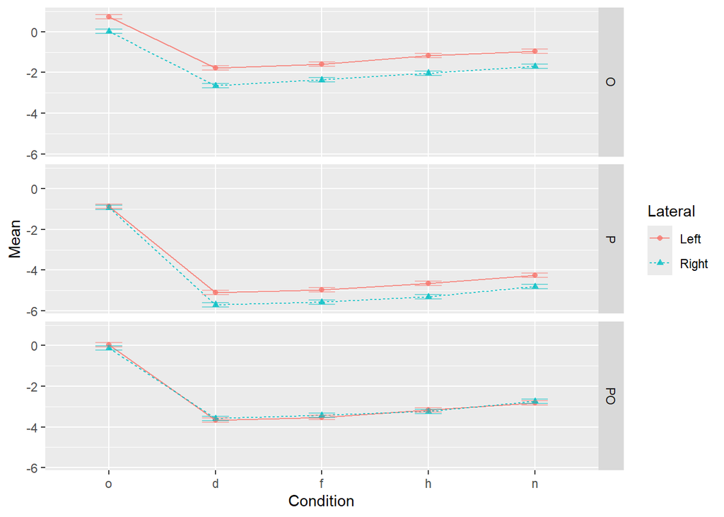

```r
ezPlot(dv=Y, wid=Subj, within=.(ChanL,Lateral,Condition),data=dati,
       x=Condition,split=Lateral,row=ChanL)
```

## 2.6 Sphericity

Sphericity is an assumption about the structure of the covariance matrix in a repeated measures design. Before we describe it, let’s consider a simpler (but more strict) condition.

**Compound symmetry**

Compound symmetry holds true when the variances within conditions are equal (this is the same as the homogeneity of variance assumption in between-group designs) but also when the covariances between pairs of conditions are roughly equal. As such, we assume that the variation within experimental conditions is fairly similar and that no two conditions are any more dependent than any other two.

Provided the observed covariances are roughly equal in our samples (and the variances are OK too) we can be pretty confident that compound symmetry is not violated.

compound symmetry is met when the correlation between `Condition f` and `Condition h` is equal to the correlation between `Condition f` and `Condition o` or `Condition h` and `Condition n`, etc (same for any other factor within subject, such as `Chan`). But a more direct way to think about compound symmetry is to say that it requires that all subjects in each group change in the same way over conditions/levels. In other words the slopes of the lines regressing the dependent variable on time are the same for all subjects. Put that way it is easy to see that compound symmetry can really be an unrealistic assumption.

**Is compound symmetry met in our data?**

```r
# install.packages("GGally")
library(GGally)
```

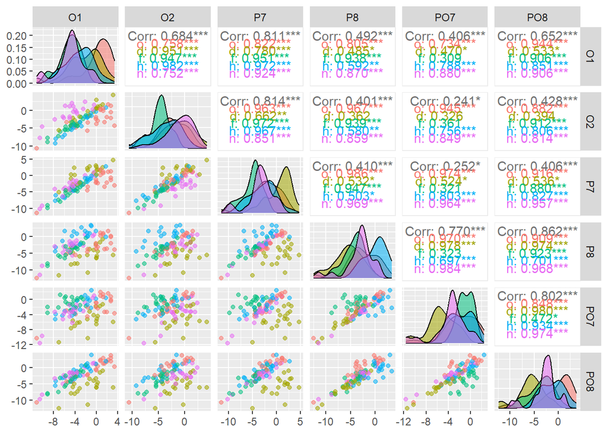

```r
Y=matrix(dati$Y,byrow = TRUE,nrow = 20*5)
Y=data.frame(Y)
names(Y)=levels(dati$Chan)
ggpairs(Y,aes(colour = dati$Condition[1:100], alpha = 0.4))
```

Not really! (correlations do often differ)

**Sphericity**

Although compound symmetry has been shown to be a sufficient condition for conducting ANOVA on repeated measures data, it is not a necessary condition. Sphericity is a less restrictive form of compound symmetry. Sphericity refers to the equality of variances of the differences between treatment levels. If you were to take each pair of treatment levels, and calculate the differences between each pair of scores it is necessary that these differences have equal variances.

We can check sphericity assumption using the covariance matrix, but it turns out to be fairly laborious. Remember that variance of differences can be computed as:
$$Var(x-y)=S^2_{x-y} = S^2_x +S^2_y -
2S_{xy}$$

Further reading: https://en.wikipedia.org/wiki/Mauchly%27s_sphericity_test

This is often an unrealistic assumption in EEG data (spatial location of channel relates to correlation between measures)

## 2.7 (Further) Limitations of Repeated Measures ANOVA

- (Design and) Data must be balanced
- Repeated Measures Anova doesn’t allow for missing data (e.g. subjects/condiction/channel cells)
- It only handle factors, no quantitative variables

Mixed model is a more flexible approach.

# 3 Mixed models

## 3.1 Motivation/Introduction

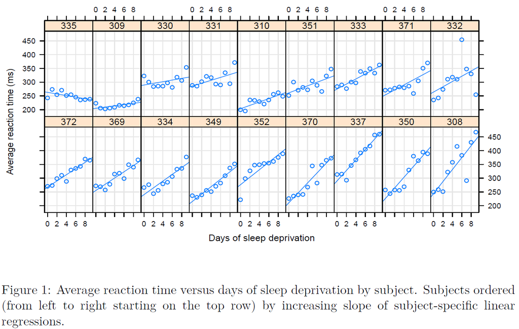

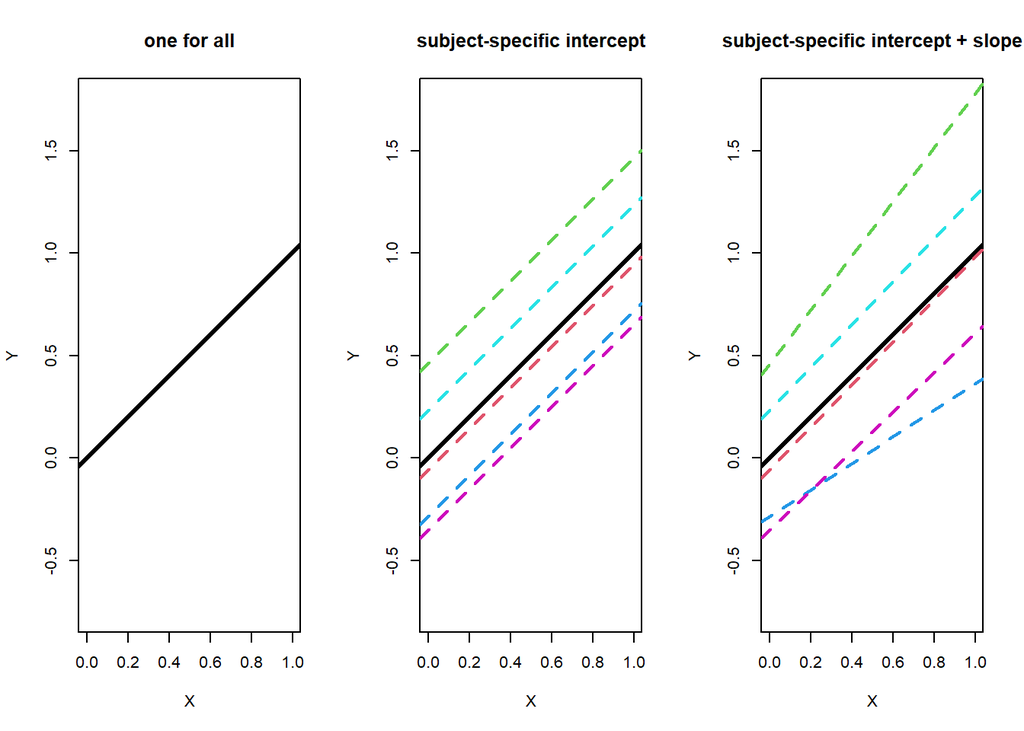

Mixed models allow for more flexible modelization.

I assume you are expert on mixed models, if not https://en.wikipedia.org/wiki/Mixed_model  
and much more on: http://webcom.upmf-grenoble.fr/LIP/Perso/DMuller/M2R/R_et_Mixed/documents/Bates-book.pdf  
and  
https://cran.r-project.org/web/packages/lme4/vignettes/lmer.pdf

## 3.2 The model

Models with random effects can be defined as:
$$Y_{n\times 1} = X_{n\times p} B_{p\times 1} +
Z_{n\times q} b_{q\times 1} + \varepsilon_{n\times 1}$$

where
$$\varepsilon\sim\mathcal{N}(
0,\sigma^2 I_n)$$

In the models we will consider, the random effects are modeled as a multivariate normal random variable:
$$b\sim\mathcal{N}(0,\Sigma_{q\times
q}),$$

In a *linear mixed model* the conditional distribution $(Y|\mathcal B=b)$ is a *spherical* multivariate Gaussian.

In our case $n=\#Subjects \times \#Conditions \times \#Channels=20\times 5 \times 6 = 600$. $X$ is the matrix of (dummified) predictors. $Z$ can take many dimensions and values. Examples follow.

**Random Intercept (for each Subject)**

$Z$ is the matrix of dummy variables of the column `dati$Subj`.

```r
library(lmerTest)
# library(lme4)
contrasts(dati$Lateral)=contr.sum
contrasts(dati$ChanL)=contr.sum
contrasts(dati$Condition)=contr.sum

mod=lmer(Y~ Condition*Lateral*ChanL +(1|Subj),data=dati)

car::Anova(mod)
```

```
## Analysis of Deviance Table (Type II Wald chisquare tests)
##
## Response: Y
##                            Chisq Df Pr(>Chisq)
## Condition               399.2932  4  < 2.2e-16 ***
## Lateral                  10.8062  1   0.001012 **
## ChanL                   323.3939  2  < 2.2e-16 ***
## Condition:Lateral         0.2827  4   0.990905
## Condition:ChanL          24.7559  8   0.001710 **
## Lateral:ChanL             6.1568  2   0.046032 *
## Condition:Lateral:ChanL   0.9461  8   0.998566
## ---
## Signif. codes:  0 '***' 0.001 '**' 0.01 '*' 0.05 '.' 0.1 ' ' 1
```

**Random Channel (for each Subject)**

Actually, instead of `Channel`, we use the combination of `ChanL*Lateral`. Same prediction ability (6 channels in Channel and 3X2 combination of ChanL and Lateral), just a different point of view.

$Z$ is the matrix of dummy variables of the column `dati$Chan`.

```r
contrasts(dati$Chan)<- contr.treatment
mod2=lmer(Y~ 1+Lateral*ChanL*Condition +(0+Chan|Subj),data=dati)
summary(mod2)
```

```
## Linear mixed model fit by REML. t-tests use Satterthwaite's method [
## lmerModLmerTest]
## Formula: Y ~ 1 + Lateral * ChanL * Condition + (0 + Chan | Subj)
##    Data: dati
##
## REML criterion at convergence: 1937.2
##
## Scaled residuals:
##     Min      1Q  Median      3Q     Max
## -4.1900 -0.4578 -0.0040  0.5130  3.5464
##
## Random effects:
##  Groups   Name    Variance Std.Dev. Corr
##  Subj     ChanO1  5.1156   2.2618
##           ChanO2  8.6139   2.9349   0.73
##           ChanP7  2.6902   1.6402   0.74 0.50
##           ChanP8  6.3837   2.5266   0.55 0.80 0.53
##           ChanPO7 5.2647   2.2945   0.87 0.54 0.95 0.56
##           ChanPO8 7.9345   2.8168   0.62 0.90 0.49 0.94 0.57
##  Residual         0.8518   0.9229
## Number of obs: 600, groups:  Subj, 20
##
## Fixed effects:
##                              Estimate Std. Error         df t value Pr(>|t|)
## (Intercept)                 -2.731516   0.467756  18.998780  -5.840 1.26e-05
## Lateral1                     0.214794   0.235212  19.000279   0.913  0.37258
## ChanL1                       1.381018   0.191777  18.998047   7.201 7.71e-07
## ChanL2                      -1.490922   0.161583  19.023042  -9.227 1.87e-08
## Condition1                   2.544305   0.075355 475.003497  33.764  < 2e-16
## Condition2                  -1.011749   0.075355 475.003497 -13.426  < 2e-16
## Condition3                  -0.849248   0.075355 475.003497 -11.270  < 2e-16
## Condition4                  -0.531397   0.075355 475.003497  -7.052 6.26e-12
## Lateral1:ChanL1              0.180370   0.110031  19.146198   1.639  0.11748
## Lateral1:ChanL2              0.032409   0.105115  19.236351   0.308  0.76115
## Lateral1:Condition1         -0.056016   0.075355 475.003497  -0.743  0.45763
## Lateral1:Condition2          0.015606   0.075355 475.003497   0.207  0.83602
## Lateral1:Condition3          0.004035   0.075355 475.003497   0.054  0.95731
## Lateral1:Condition4          0.049614   0.075355 475.003497   0.658  0.51060
## ChanL1:Condition1           -0.811645   0.106568 475.003497  -7.616 1.42e-13
## ChanL2:Condition1            0.771993   0.106568 475.003497   7.244 1.77e-12
```

[output cut: 32 more lines]

```
## ChanL2:Condition2
## ChanL1:Condition3          *
## ChanL2:Condition3          .
## ChanL1:Condition4          **
## ChanL2:Condition4          *
## Lateral1:ChanL1:Condition1
## Lateral1:ChanL2:Condition1
## Lateral1:ChanL1:Condition2
## Lateral1:ChanL2:Condition2
## Lateral1:ChanL1:Condition3
## Lateral1:ChanL2:Condition3
## Lateral1:ChanL1:Condition4
## Lateral1:ChanL2:Condition4
## ---
## Signif. codes:  0 '***' 0.001 '**' 0.01 '*' 0.05 '.' 0.1 ' ' 1
```

```
##
## Correlation matrix not shown by default, as p = 30 > 12.
## Use print(x, correlation=TRUE)  or
##     vcov(x)        if you need it
```

```r
car::Anova(mod2)
```

```
## Analysis of Deviance Table (Type II Wald chisquare tests)
##
## Response: Y
##                             Chisq Df Pr(>Chisq)
## Lateral                    6.0188  1    0.01415 *
## ChanL                     81.2568  2  < 2.2e-16 ***
## Condition               1200.8872  4  < 2.2e-16 ***
## Lateral:ChanL              7.7571  2    0.02068 *
## Lateral:Condition          0.8502  4    0.93160
## ChanL:Condition           74.4541  8  6.344e-13 ***
## Lateral:ChanL:Condition    2.8456  8    0.94367
## ---
## Signif. codes:  0 '***' 0.001 '**' 0.01 '*' 0.05 '.' 0.1 ' ' 1
```

```r
# More flexible, but harder to fit (note that independence among random effects is imposed):
# mod3=lmer(Y~ Condition*ChanL+Lateral+(0+Lateral|Subj)+(0+Condition|Subj)+(0+ChanL|Subj),data=dati)
#
```

**Random Emisphere (for each Subject)**

A simplified model may be based on Left/Right random effect for each subject.

```r
mod3=lmer(Y~ Lateral*ChanL*Condition +(1+Lateral|Subj),data=dati)
summary(mod3)
```

```
## Linear mixed model fit by REML. t-tests use Satterthwaite's method [
## lmerModLmerTest]
## Formula: Y ~ Lateral * ChanL * Condition + (1 + Lateral | Subj)
##    Data: dati
##
## REML criterion at convergence: 2130.3
##
## Scaled residuals:
##      Min       1Q   Median       3Q      Max
## -2.96741 -0.57945  0.03594  0.60345  2.56829
##
## Random effects:
##  Groups   Name        Variance Std.Dev. Corr
##  Subj     (Intercept) 4.327    2.080
##           Lateral1    1.057    1.028    -0.37
##  Residual             1.468    1.212
## Number of obs: 600, groups:  Subj, 20
##
## Fixed effects:
##                              Estimate Std. Error         df t value Pr(>|t|)
## (Intercept)                 -2.731516   0.467735  18.999757  -5.840 1.26e-05
## Lateral1                     0.214794   0.235191  19.000133   0.913   0.3725
## ChanL1                       1.381018   0.069948 532.000111  19.743  < 2e-16
## ChanL2                      -1.490922   0.069948 532.000111 -21.315  < 2e-16
## Condition1                   2.544305   0.098922 532.000111  25.720  < 2e-16
## Condition2                  -1.011749   0.098922 532.000111 -10.228  < 2e-16
## Condition3                  -0.849248   0.098922 532.000111  -8.585  < 2e-16
## Condition4                  -0.531397   0.098922 532.000111  -5.372 1.17e-07
## Lateral1:ChanL1              0.180370   0.069948 532.000111   2.579   0.0102
## Lateral1:ChanL2              0.032409   0.069948 532.000111   0.463   0.6433
## Lateral1:Condition1         -0.056016   0.098922 532.000111  -0.566   0.5715
## Lateral1:Condition2          0.015606   0.098922 532.000111   0.158   0.8747
## Lateral1:Condition3          0.004035   0.098922 532.000111   0.041   0.9675
## Lateral1:Condition4          0.049614   0.098922 532.000111   0.502   0.6162
## ChanL1:Condition1           -0.811645   0.139897 532.000111  -5.802 1.13e-08
## ChanL2:Condition1            0.771993   0.139897 532.000111   5.518 5.35e-08
## ChanL1:Condition2            0.149199   0.139897 532.000111   1.066   0.2867
## ChanL2:Condition2           -0.167232   0.139897 532.000111  -1.195   0.2325
## ChanL1:Condition3            0.213801   0.139897 532.000111   1.528   0.1270
## ChanL2:Condition3           -0.204413   0.139897 532.000111  -1.461   0.1446
```

[output cut: 28 more lines]

```
## ChanL2:Condition2
## ChanL1:Condition3
## ChanL2:Condition3
## ChanL1:Condition4          *
## ChanL2:Condition4          .
## Lateral1:ChanL1:Condition1
## Lateral1:ChanL2:Condition1
## Lateral1:ChanL1:Condition2
## Lateral1:ChanL2:Condition2
## Lateral1:ChanL1:Condition3
## Lateral1:ChanL2:Condition3
## Lateral1:ChanL1:Condition4
## Lateral1:ChanL2:Condition4
## ---
## Signif. codes:  0 '***' 0.001 '**' 0.01 '*' 0.05 '.' 0.1 ' ' 1
```

```
##
## Correlation matrix not shown by default, as p = 30 > 12.
## Use print(x, correlation=TRUE)  or
##     vcov(x)        if you need it
```

```r
car::Anova(mod3)
```

```
## Analysis of Deviance Table (Type II Wald chisquare tests)
##
## Response: Y
##                            Chisq Df Pr(>Chisq)
## Lateral                   0.8341  1   0.361099
## ChanL                   564.3879  2  < 2.2e-16 ***
## Condition               696.8476  4  < 2.2e-16 ***
## Lateral:ChanL            10.7449  2   0.004643 **
## Lateral:Condition         0.4933  4   0.974146
## ChanL:Condition          43.2040  8   8.04e-07 ***
## Lateral:ChanL:Condition   1.6512  8   0.989903
## ---
## Signif. codes:  0 '***' 0.001 '**' 0.01 '*' 0.05 '.' 0.1 ' ' 1
```

## 3.3 Plotting tools

for the first model:

```r
library(effects)
```

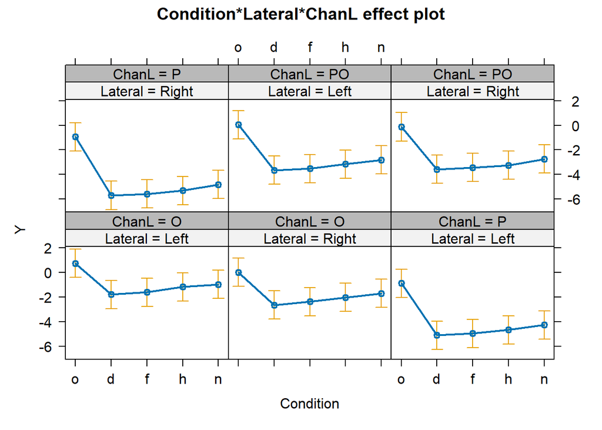

```r
plot(allEffects(mod))
```

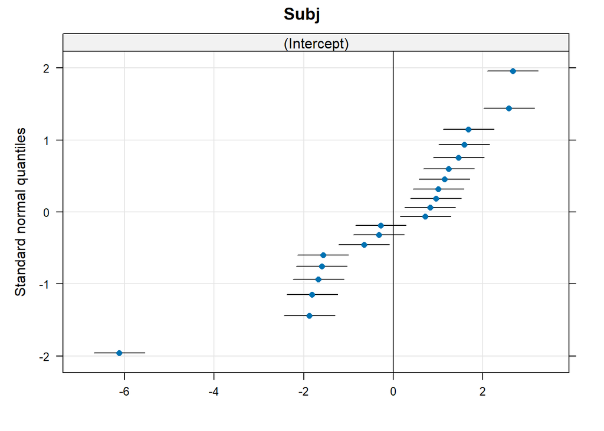

```r
#plot random effects:
require(lattice)
qqmath(ranef(mod, condVar=TRUE))
```

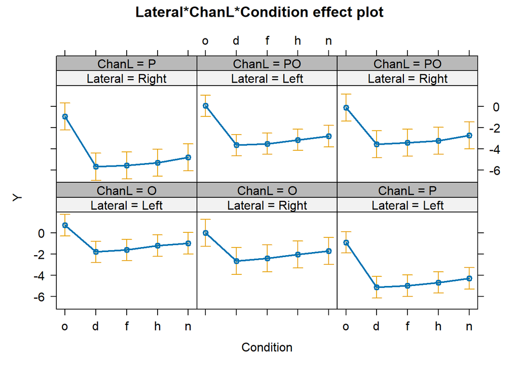

```r
library(effects)
plot(allEffects(mod3))
```

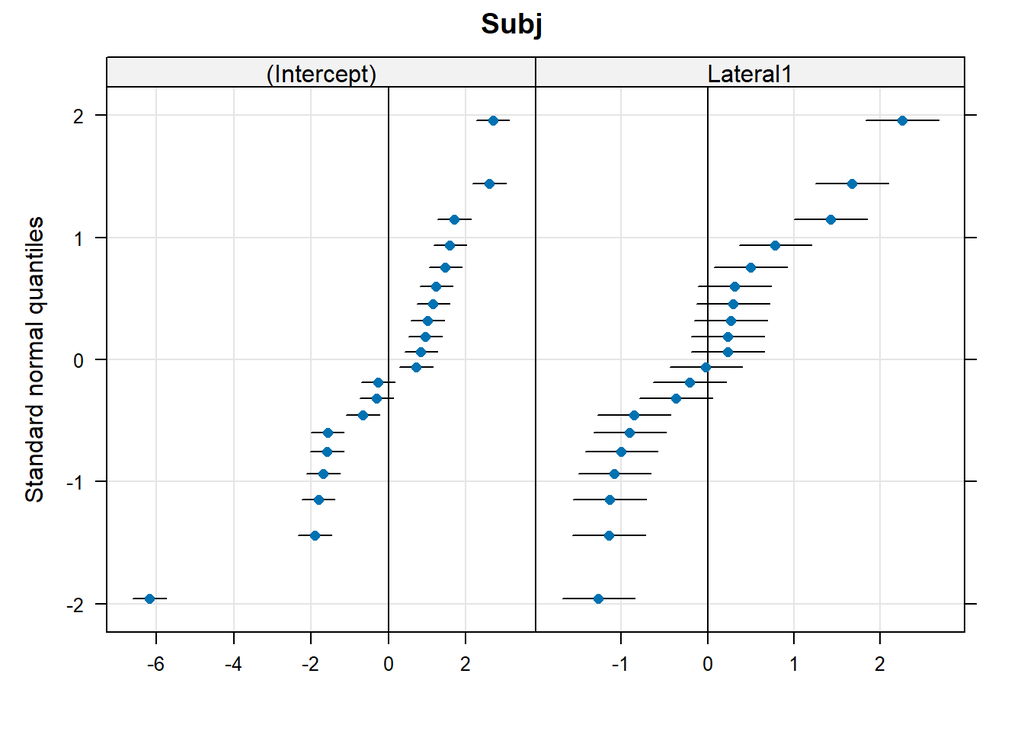

```r
#plot random effects:
require(lattice)
qqmath(ranef(mod3, condVar=TRUE))
```

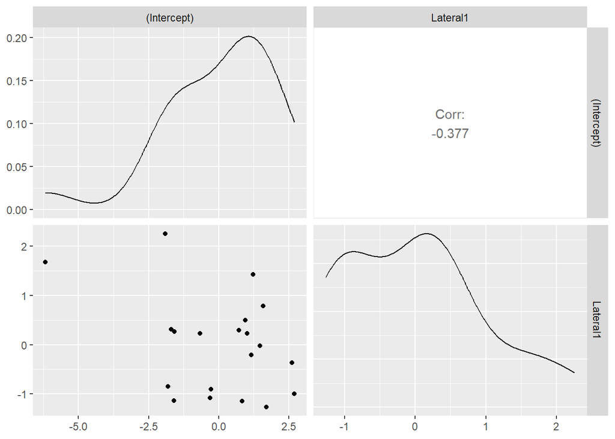

```r
# scatter plot
ggpairs(ranef(mod3, condVar=TRUE)$Subj)
```

An alternative plotting tool:

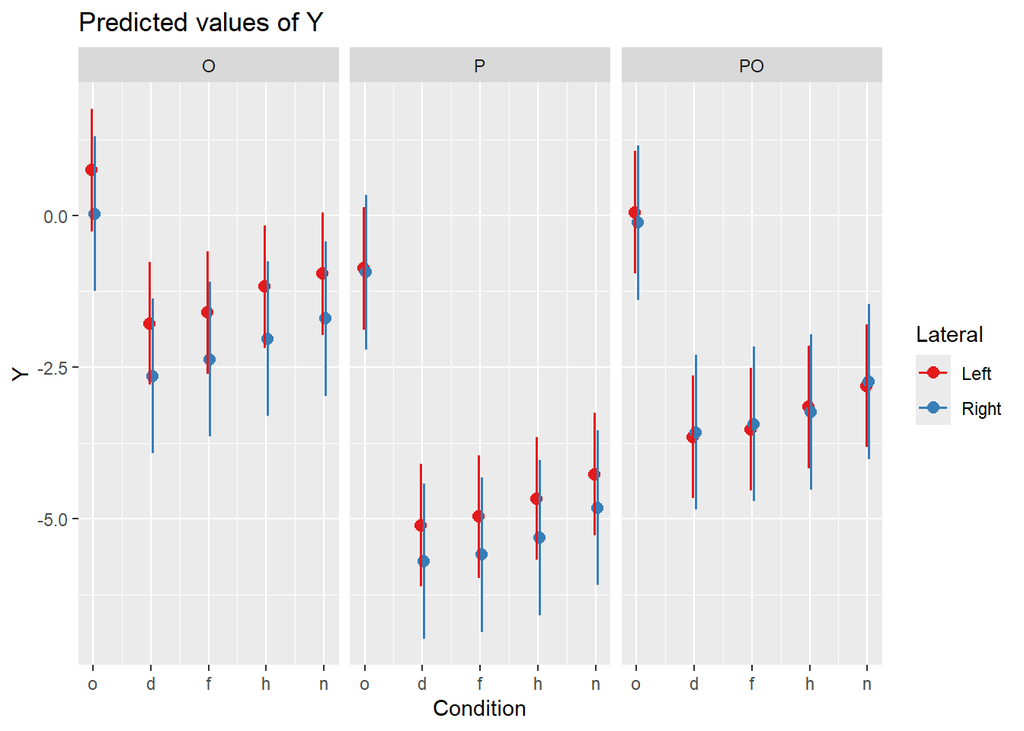

```r
library(sjPlot)
library(ggplot2)
plot_model(mod3, type = "pred", terms = c("Condition","Lateral", "ChanL"))
```

## 3.4 Validity of the assumptions

- Independence of the residuals?
- Normality of the residuals?
- Homoscedasticity of the residuals (i.e. same variance between subject/channel/condition)?
- outliers?
- Leaverage? (influential observations)

Please, do not test for normality, for homoscedasticity, sphericity etc.

Use Exploratory data Analysis, instead!

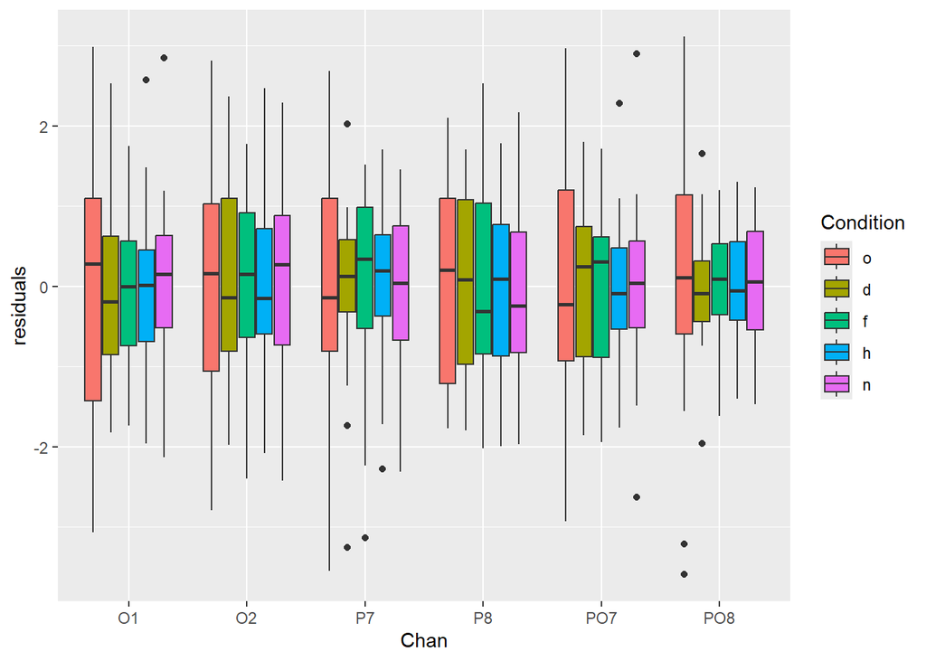

```r
dati$residuals=residuals(mod3)
p <- ggplot(dati, aes(x=Chan, y=residuals,fill=Condition)) +   geom_boxplot()
p
```

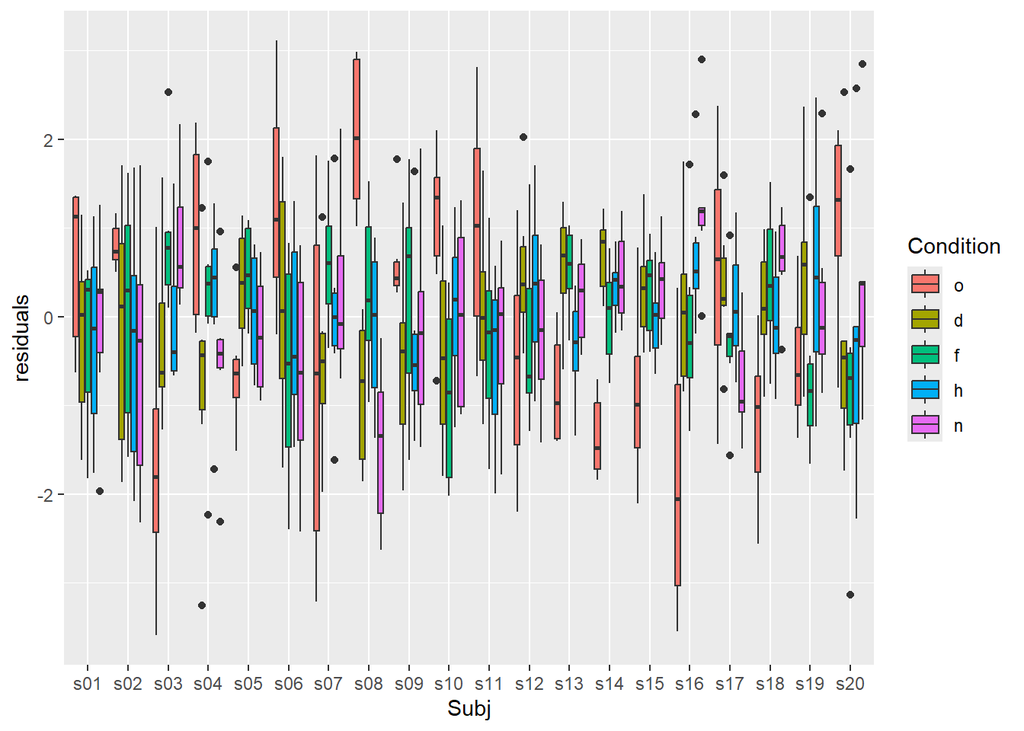

```r
p <- ggplot(dati, aes(x=Subj, y=residuals,fill=Condition)) +   geom_boxplot()
p
```

## 3.5 Contrasts and post-hoc

### 3.5.1 Post-hoc

```r
library(multcomp)
summary(glht(mod3, linfct = mcp(Condition = "Tukey")))
```

```
##
##   Simultaneous Tests for General Linear Hypotheses
##
## Multiple Comparisons of Means: Tukey Contrasts
##
##
## Fit: lmer(formula = Y ~ Lateral * ChanL * Condition + (1 + Lateral |
##     Subj), data = dati)
##
## Linear Hypotheses:
##            Estimate Std. Error z value Pr(>|z|)
## d - o == 0  -3.5561     0.1564 -22.736   <0.001 ***
## f - o == 0  -3.3936     0.1564 -21.697   <0.001 ***
## h - o == 0  -3.0757     0.1564 -19.664   <0.001 ***
## n - o == 0  -2.6962     0.1564 -17.238   <0.001 ***
## f - d == 0   0.1625     0.1564   1.039    0.837
## h - d == 0   0.4804     0.1564   3.071    0.018 *
## n - d == 0   0.8598     0.1564   5.497   <0.001 ***
## h - f == 0   0.3179     0.1564   2.032    0.250
## n - f == 0   0.6973     0.1564   4.458   <0.001 ***
## n - h == 0   0.3795     0.1564   2.426    0.108
## ---
## Signif. codes:  0 '***' 0.001 '**' 0.01 '*' 0.05 '.' 0.1 ' ' 1
## (Adjusted p values reported -- single-step method)
```

### 3.5.2 Custom contrasts

An example:

- neutral vs object in O1 (left)
- disgust vs neutral in O1 (left)
- fear vs neutral in O1 (left)
- happy vs neutral in O1 (left)

```r
library(multcomp)
ncoeff=length(coefficients(mod3)[[1]])
contr <- rbind("n - o" = c(0,0,0,0,-1, 0, 0, 0, rep(0,ncoeff-8)),
               "d - n" = c(0,0,0,0, 0, 1, 0, 0, rep(0,ncoeff-8)),
               "f - n" = c(0,0,0,0, 0, 0, 1, 0, rep(0,ncoeff-8)),
               "h - n" = c(0,0,0,0, 0, 0, 0, 1, rep(0,ncoeff-8)))
compa= glht(mod3, linfct = contr)
summary(compa, test = adjusted("none"))
```

```
##
##   Simultaneous Tests for General Linear Hypotheses
##
## Fit: lmer(formula = Y ~ Lateral * ChanL * Condition + (1 + Lateral |
##     Subj), data = dati)
##
## Linear Hypotheses:
##            Estimate Std. Error z value Pr(>|z|)
## n - o == 0 -2.54431    0.09892 -25.720  < 2e-16 ***
## d - n == 0 -1.01175    0.09892 -10.228  < 2e-16 ***
## f - n == 0 -0.84925    0.09892  -8.585  < 2e-16 ***
## h - n == 0 -0.53140    0.09892  -5.372 7.79e-08 ***
## ---
## Signif. codes:  0 '***' 0.001 '**' 0.01 '*' 0.05 '.' 0.1 ' ' 1
## (Adjusted p values reported -- none method)
```

```r
# with multiple comparisons
summary(compa)
```

```
##
##   Simultaneous Tests for General Linear Hypotheses
##
## Fit: lmer(formula = Y ~ Lateral * ChanL * Condition + (1 + Lateral |
##     Subj), data = dati)
##
## Linear Hypotheses:
##            Estimate Std. Error z value Pr(>|z|)
## n - o == 0 -2.54431    0.09892 -25.720  < 1e-07 ***
## d - n == 0 -1.01175    0.09892 -10.228  < 1e-07 ***
## f - n == 0 -0.84925    0.09892  -8.585  < 1e-07 ***
## h - n == 0 -0.53140    0.09892  -5.372 2.53e-07 ***
## ---
## Signif. codes:  0 '***' 0.001 '**' 0.01 '*' 0.05 '.' 0.1 ' ' 1
## (Adjusted p values reported -- single-step method)
```

# 4 Multivariate ANOVA (MANOVA)

## 4.1 Motivation

Hei, wait a moment… the trials for `object` condition are much more than any other condition, the variance of its estimated component must be (much?) lower, homoschedastcity doesn’t hold!!

Let’s use a different approach Reshape the data from `long` to `wide` format.

## 4.2 Reshaping the data

Let’ now compute the vectors of contrasts (one vector of reach channel, length equal to number of subjects): `Happy vs Neutral`

```r
Y=matrix(dati$Y,byrow = TRUE,nrow = 20)
colnames(Y)=paste(dati$Condition,dati$ChanL,dati$Lateral,sep = "_")[1:30]
```

```r
colnames(Y)
```

```
##  [1] "f_P_Left"   "h_P_Left"   "d_P_Left"   "n_P_Left"   "o_P_Left"
##  [6] "f_PO_Left"  "h_PO_Left"  "d_PO_Left"  "n_PO_Left"  "o_PO_Left"
## [11] "f_O_Left"   "h_O_Left"   "d_O_Left"   "n_O_Left"   "o_O_Left"
## [16] "f_P_Right"  "h_P_Right"  "d_P_Right"  "n_P_Right"  "o_P_Right"
## [21] "f_PO_Right" "h_PO_Right" "d_PO_Right" "n_PO_Right" "o_PO_Right"
## [26] "f_O_Right"  "h_O_Right"  "d_O_Right"  "n_O_Right"  "o_O_Right"
```

```r
contr=matrix(0,30,6)
contr[c(2,4),1]=c(1,-1)
contr[c(2,4)+5,2]=c(1,-1)
contr[c(2,4)+10,3]=c(1,-1)
contr[c(2,4)+15,4]=c(1,-1)
contr[c(2,4)+20,5]=c(1,-1)
contr[c(2,4)+25,6]=c(1,-1)

dim(contr)
```

```
## [1] 30  6
```

```r
head(contr)
```

```
##      [,1] [,2] [,3] [,4] [,5] [,6]
## [1,]    0    0    0    0    0    0
## [2,]    1    0    0    0    0    0
## [3,]    0    0    0    0    0    0
## [4,]   -1    0    0    0    0    0
## [5,]    0    0    0    0    0    0
## [6,]    0    0    0    0    0    0
```

```r
Yhn=Y%*%contr
colnames(Yhn)= levels(dati$Chan)
dim(Yhn)
```

```
## [1] 20  6
```

What we see in O1?

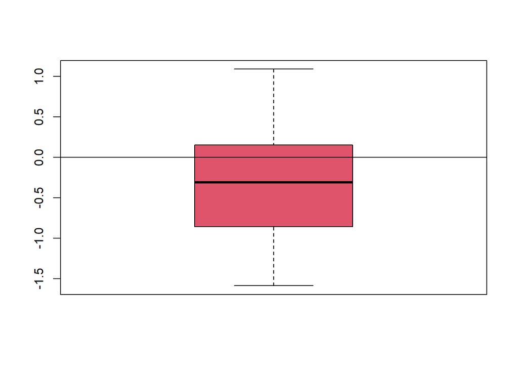

```r
boxplot(Yhn[,1],col=2)
abline(0,0)
```

Same test as above, but under a different model

```r
t.test(Yhn[,1])
```

```
##
##  One Sample t-test
##
## data:  Yhn[, 1]
## t = -2.4493, df = 19, p-value = 0.02418
## alternative hypothesis: true mean is not equal to 0
## 95 percent confidence interval:
##  -0.73552954 -0.05769046
## sample estimates:
## mean of x
##  -0.39661
```

We can run the analysis over all channels

```r
(uni_t=apply(Yhn,2,t.test))
```

```
## $O1
##
##  One Sample t-test
##
## data:  newX[, i]
## t = -2.4493, df = 19, p-value = 0.02418
## alternative hypothesis: true mean is not equal to 0
## 95 percent confidence interval:
##  -0.73552954 -0.05769046
## sample estimates:
## mean of x
##  -0.39661
##
##
## $O2
##
##  One Sample t-test
##
## data:  newX[, i]
## t = -2.3752, df = 19, p-value = 0.02822
## alternative hypothesis: true mean is not equal to 0
## 95 percent confidence interval:
##  -0.64355774 -0.04064226
## sample estimates:
## mean of x
##   -0.3421
##
##
## $P7
##
##  One Sample t-test
##
## data:  newX[, i]
## t = -1.4718, df = 19, p-value = 0.1574
## alternative hypothesis: true mean is not equal to 0
## 95 percent confidence interval:
##  -0.51150297  0.08913297
## sample estimates:
## mean of x
## -0.211185
```

[output cut: 27 more lines]

```
## -0.501065
##
##
## $PO8
##
##  One Sample t-test
##
## data:  newX[, i]
## t = -2.1369, df = 19, p-value = 0.04583
## alternative hypothesis: true mean is not equal to 0
## 95 percent confidence interval:
##  -0.653973307 -0.006776693
## sample estimates:
## mean of x
## -0.330375
```

## 4.3 Manova

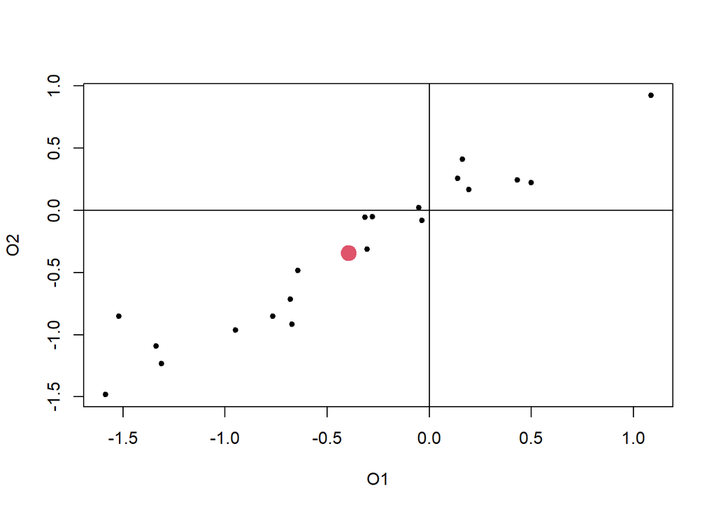

```r
plot(Yhn[,1:2],pch=20)
abline(v=0)
abline(h=0)
points(mean(Yhn[,1]),mean(Yhn[,2]),cex=3,col=2,pch=20)
```

```r
modman <- manova(Yhn ~ 1)
anova(modman)
```

```
## Analysis of Variance Table
##
##             Df  Pillai approx F num Df den Df  Pr(>F)
## (Intercept)  1 0.55314   2.8882      6     14 0.04782 *
## Residuals   19
## ---
## Signif. codes:  0 '***' 0.001 '**' 0.01 '*' 0.05 '.' 0.1 ' ' 1
```

```r
# equivalent to anova(modman,manova(Yhn ~ 0))
```

Assumptions: multivariate normality

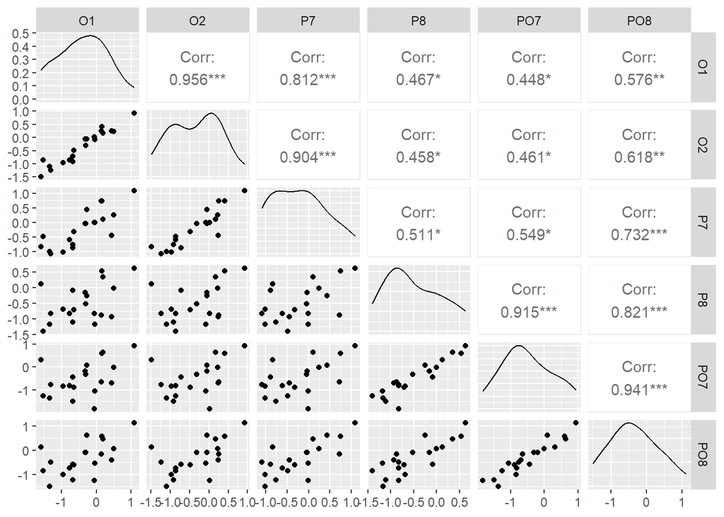

```r
ggpairs(data.frame(Yhn))
```

Not so bad, actually.

# 5 Mapping results on a scalp

```r
# install.packages("eegkit")
library(eegkit)
```

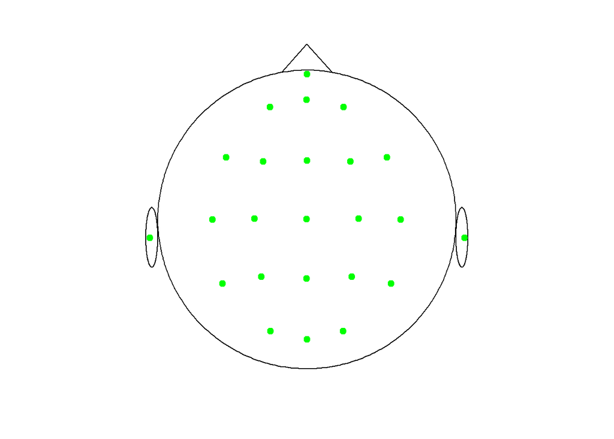

```r
# plot 2d cap without labels
eegcap("10-20", plotlabels = FALSE)
```

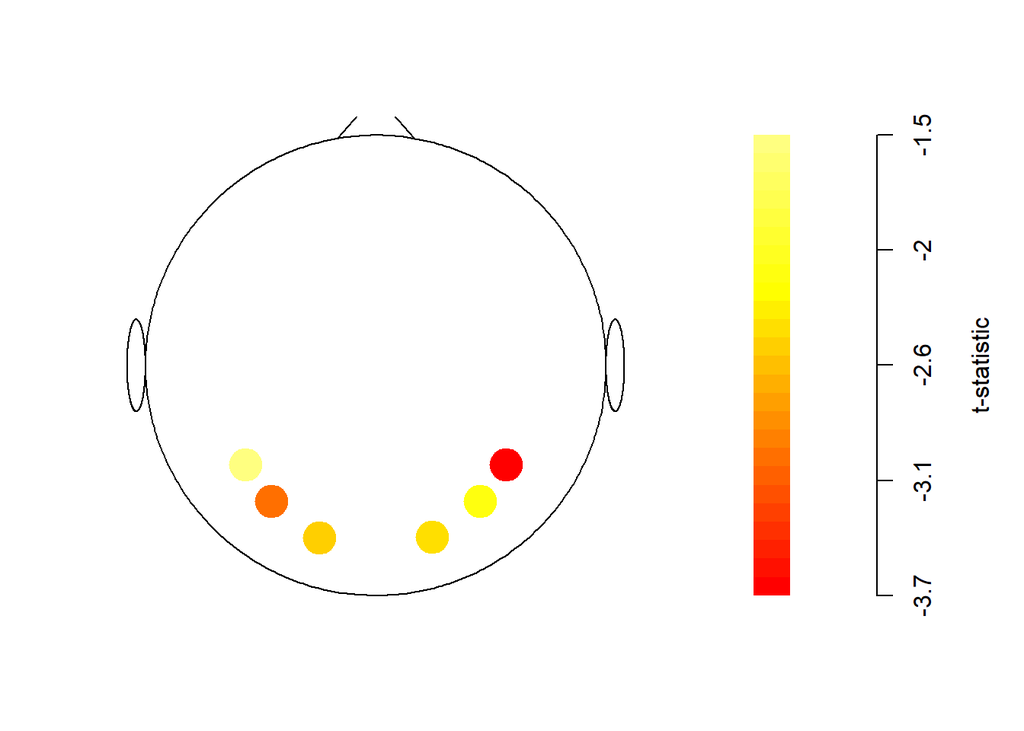

```r
# get the t-statistic for each channel:
t_chan=sapply(uni_t,function(chan)chan$statistic)
names(t_chan)=gsub("\\.t","",names(t_chan))

# match to eeg coordinates
data(eegcoord)
cidx <- match(names(t_chan),rownames(eegcoord))

# # plot t-stat in 3d
#  open3d()
# eegspace(eegcoord[cidx,1:3],t_chan)

# plot t-stat in 2d
eegspace(eegcoord[cidx,4:5],t_chan,cex.point = 3,colorlab="t-statistic",mycolors=heat.colors(4))
```

I suggest you to play with much nicer plots (based on library `ggplot2`):  
- package eeguana https://github.com/bnicenboim/eeguana  
- package eegUtils https://github.com/craddm/eegUtils

# 6 (minimal) Bibliography

## 6.1 About (generalizzed) linear Mixed models:

lme4 package https://cran.r-project.org/web/packages/lme4/vignettes/lmer.pdf

Jonathan Baron (2011) Notes on the use of R for psychology experiments and questionnaires https://www.sas.upenn.edu/~baron/from_cattell/rpsych/rpsych.html

Pinheiro, J., & Bates, D. (2006) Mixed-effects models in S and S-PLUS. https://www.springer.com/gp/book/9780387954580

Bates, D. (2022) lme4: Mixed-effects modeling with R. https://stat.ethz.ch/~maechler/MEMo-pages/lMMwR.pdf

Fox, J. (2015) Applied regression analysis and generalized linear models. https://us.sagepub.com/en-us/nam/applied-regression-analysis-and-generalized-linear-models/book246125

Fox, J., & Weisberg, S. (2018) An R companion to applied regression. https://us.sagepub.com/en-us/nam/an-r-companion-to-applied-regression/book246125

Bliese, P. (2022) Multilevel modeling in R (2.7). https://cran.r-project.org/doc/contrib/Bliese_Multilevel.pdf

Baayen, R. H., Davidson, D. J., & Bates, D. M. (2008) Mixed-effects modeling with crossed random effects for subjects and items. https://doi.org/10.1016/j.jml.2007.12.005

Bürkner, P. C. (2017) brms: An R package for Bayesian multilevel models using Stan. https://doi.org/10.18637/jss.v080.i01

McElreath, R. (2020) Statistical rethinking: A Bayesian course with examples in R and Stan. https://xcelab.net/rm/statistical-rethinking/

GLMM FAQ by Ben Bolker and others https://bbolker.github.io/mixedmodels-misc/glmmFAQ.html

A complete course on mixed models (in italian) https://osf.io/b7tkp/

## 6.2 Resampling based:

The bridge between rep meas. ANOVA and Mixed Models is built and developed by (very nice job (!), by the way):

https://jaromilfrossard.github.io/gANOVA/

https://jaromilfrossard.github.io/gANOVA/articles/spherical-distribution-example.html

https://arxiv.org/abs/1903.10766

## 6.3 More

About Type I error, II, III SS: https://mcfromnz.wordpress.com/2011/03/02/anova-type-iiiiii-ss-explained/